# 更多模型

# 目录

- 1 前提准备
- 2 `gapminder` 数据集
  - 2.1 嵌套数据框
  - 2.2 列表-列
  - 2.3 解嵌套
  - 2.4 模型评价
- 3 列表-列
- 4 创建列表-列
  - 4.1 `nest()` 函数
  - 4.2 返回列表的向量化函数
  - 4.3 返回多结果的汇总函数
  - 4.4 有命名的列表
- 5 列表-列转换为常规列
  - 5.1 列表-列转换为向量
  - 5.2 解嵌套
- 6 用 `broom` 包创建规整数据

# 1 前提准备

```r
library(modelr)
library(tidyverse)
```

# 2 `gapminder` 数据集

```r
library(gapminder)
```

```r
gapminder
```

| country | continent | year | lifeExp | pop | gdpPercap |
| --- | --- | --- | --- | --- | --- |
| Afghanistan | Asia | 1952 | 28.80100 | 8425333 | 779.4453 |
| Afghanistan | Asia | 1957 | 30.33200 | 9240934 | 820.8530 |
| Afghanistan | Asia | 1962 | 31.99700 | 10267083 | 853.1007 |
| Afghanistan | Asia | 1967 | 34.02000 | 11537966 | 836.1971 |
| Afghanistan | Asia | 1972 | 36.08800 | 13079460 | 739.9811 |
| Afghanistan | Asia | 1977 | 38.43800 | 14880372 | 786.1134 |
| Afghanistan | Asia | 1982 | 39.85400 | 12881816 | 978.0114 |
| Afghanistan | Asia | 1987 | 40.82200 | 13867957 | 852.3959 |
| Afghanistan | Asia | 1992 | 41.67400 | 16317921 | 649.3414 |
| Afghanistan | Asia | 1997 | 41.76300 | 22227415 | 635.3414 |

[output cut: 990 more lines]

```
#> # A tibble: 1,704 × 6
#>       country continent  year lifeExp      pop gdpPercap
#>        <fctr>    <fctr> <int>   <dbl>    <int>     <dbl>
#> 1 Afghanistan      Asia  1952    28.8  8425333       779
#> 2 Afghanistan      Asia  1957    30.3  9240934       821
#> 3 Afghanistan      Asia  1962    32.0 10267083       853
#> 4 Afghanistan      Asia  1967    34.0 11537966       836
#> 5 Afghanistan      Asia  1972    36.1 13079460       740
#> 6 Afghanistan      Asia  1977    38.4 14880372       786
#> # ... with 1,698 more rows
```

使用三个变量，来回答以下问题：不同国家（`country`）的期望寿命（`lifeExp`）是如何随着时间（`year`）变化的？

首先绘制不同国家期望寿命随时间变化的折线图：

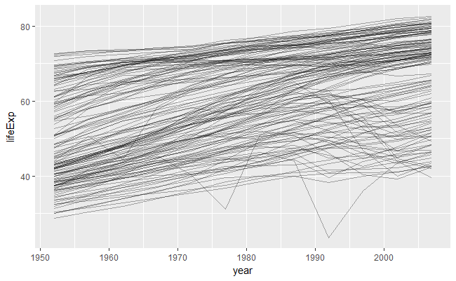

```r
gapminder %>%
  ggplot(aes(year, lifeExp, group = country)) +
    geom_line(alpha = 1/3)
```

总的来说，一国的期望寿命随着时间稳步提高，但是也有一些国家并未遵循这一规律。建立线性回归模型，剔除时间因素：

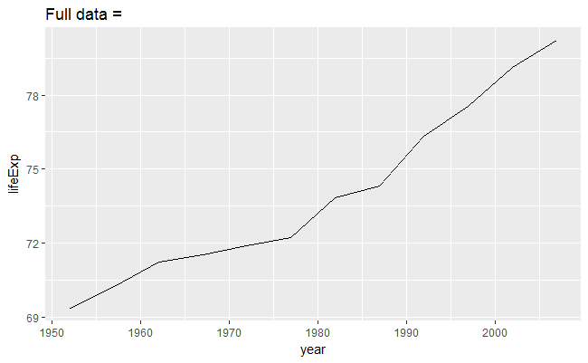

```r
nz <- filter(gapminder, country == "New Zealand")
nz %>%
  ggplot(aes(year, lifeExp)) +
  geom_line() +
  ggtitle("Full data = ")
```

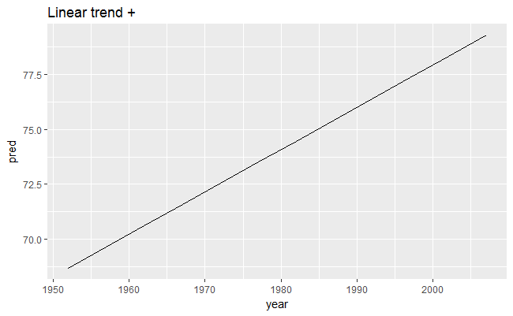

```r
nz_mod <- lm(lifeExp ~ year, data = nz)
nz %>%
  add_predictions(nz_mod) %>%
  ggplot(aes(year, pred)) +
  geom_line() +
  ggtitle("Linear trend + ")
```

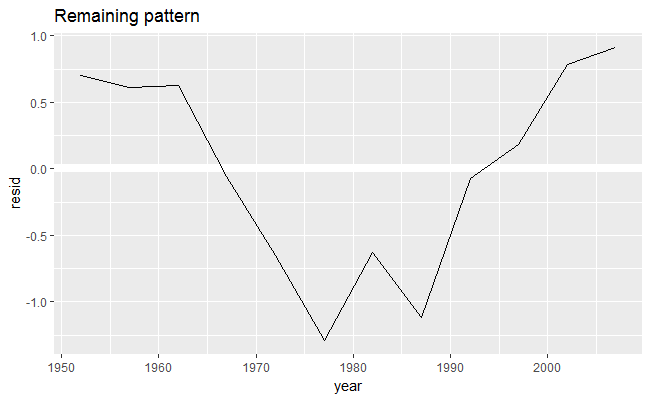

```r
nz %>%
  add_residuals(nz_mod) %>%
  ggplot(aes(year, resid)) +
  geom_hline(yintercept = 0, colour = "white", size = 3) +
  geom_line() +
  ggtitle("Remaining pattern")
```

如何对所有国家进行同样的操作呢？

## 2.1 嵌套数据框

不同于使用 `purrr` 中的 `map` 函数族来对列进行循环操作，这里要针对不同国家进行循环操作，即对行进行循环操作。为了达到这一目的，需要借助**嵌套数据框（nested data frame）**，使用 `nest()` 函数：

```r
by_country <- gapminder %>%
  group_by(country, continent) %>%
  nest()
by_country
```

| country | continent | data |
| --- | --- | --- |
| Afghanistan | Asia |  |
| Albania | Europe |  |
| Algeria | Africa |  |
| Angola | Africa |  |
| Argentina | Americas |  |
| Australia | Oceania |  |
| Austria | Europe |  |
| Bahrain | Asia |  |
| Bangladesh | Asia |  |
| Belgium | Europe |  |

[output cut: 132 more lines]

```
#> # A tibble: 142 × 3
#>       country continent              data
#>        <fctr>    <fctr>            <list>
#> 1 Afghanistan      Asia <tibble [12 × 4]>
#> 2     Albania    Europe <tibble [12 × 4]>
#> 3     Algeria    Africa <tibble [12 × 4]>
#> 4      Angola    Africa <tibble [12 × 4]>
#> 5   Argentina  Americas <tibble [12 × 4]>
#> 6   Australia   Oceania <tibble [12 × 4]>
#> # ... with 136 more rows
```

嵌套数据框中每一行都代表一个分组， `data` 一列由数据框构成，包含了该分组的所有数据：

```r
by_country$data[[1]]
```

| year | lifeExp | pop | gdpPercap |
| --- | --- | --- | --- |
| 1952 | 28.801 | 8425333 | 779.4453 |
| 1957 | 30.332 | 9240934 | 820.8530 |
| 1962 | 31.997 | 10267083 | 853.1007 |
| 1967 | 34.020 | 11537966 | 836.1971 |
| 1972 | 36.088 | 13079460 | 739.9811 |
| 1977 | 38.438 | 14880372 | 786.1134 |
| 1982 | 39.854 | 12881816 | 978.0114 |
| 1987 | 40.822 | 13867957 | 852.3959 |
| 1992 | 41.674 | 16317921 | 649.3414 |
| 1997 | 41.763 | 22227415 | 635.3414 |

[output cut: 2 more lines]

```
#> # A tibble: 12 × 4
#>    year lifeExp      pop gdpPercap
#>   <int>   <dbl>    <int>     <dbl>
#> 1  1952    28.8  8425333       779
#> 2  1957    30.3  9240934       821
#> 3  1962    32.0 10267083       853
#> 4  1967    34.0 11537966       836
#> 5  1972    36.1 13079460       740
#> 6  1977    38.4 14880372       786
#> # ... with 6 more rows
```

注意分组后的数据框和嵌套数据框的区别：分组后的数据框，每一行仍然代表一个观测；嵌套数据框，每一行代表一个分组。

## 2.2 列表-列

编写一个建立模型的函数：

```r
country_model <- function(df) {
  lm(lifeExp ~ year, data = df)
}
```

由于 `data` 列相当于一个列表，可以通过 `purrr::map()` 函数来对每个元素循环使用 `country_model()` 函数：

```r
models <- map(by_country$data, country_model)
```

可以将 `models` 存储为 `by_country` 的一个列表-列：

```r
by_country <- by_country %>%
  mutate(model = map(data, country_model))
by_country
```

| country | continent | data | model |
| --- | --- | --- | --- |
| Afghanistan | Asia |  |  |
| Albania | Europe |  |  |
| Algeria | Africa |  |  |
| Angola | Africa |  |  |
| Argentina | Americas |  |  |
| Australia | Oceania |  |  |
| Austria | Europe |  |  |
| Bahrain | Asia |  |  |
| Bangladesh | Asia |  |  |
| Belgium | Europe |  |  |

[output cut: 132 more lines]

```
#> # A tibble: 142 × 4
#>       country continent              data    model
#>        <fctr>    <fctr>            <list>   <list>
#> 1 Afghanistan      Asia <tibble [12 × 4]> <S3: lm>
#> 2     Albania    Europe <tibble [12 × 4]> <S3: lm>
#> 3     Algeria    Africa <tibble [12 × 4]> <S3: lm>
#> 4      Angola    Africa <tibble [12 × 4]> <S3: lm>
#> 5   Argentina  Americas <tibble [12 × 4]> <S3: lm>
#> 6   Australia   Oceania <tibble [12 × 4]> <S3: lm>
#> # ... with 136 more rows
```

这样做的好处在于，所有的数据和模型储存在一起，可以同时对它们进行操作：

```r
by_country %>%
  filter(continent == "Europe")
```

| country | continent | data | model |
| --- | --- | --- | --- |
| Albania | Europe |  |  |
| Austria | Europe |  |  |
| Belgium | Europe |  |  |
| Bosnia and Herzegovina | Europe |  |  |
| Bulgaria | Europe |  |  |
| Croatia | Europe |  |  |
| Czech Republic | Europe |  |  |
| Denmark | Europe |  |  |
| Finland | Europe |  |  |
| France | Europe |  |  |

[output cut: 20 more lines]

```
#> # A tibble: 30 × 4
#>                  country continent              data    model
#>                   <fctr>    <fctr>            <list>   <list>
#> 1                Albania    Europe <tibble [12 × 4]> <S3: lm>
#> 2                Austria    Europe <tibble [12 × 4]> <S3: lm>
#> 3                Belgium    Europe <tibble [12 × 4]> <S3: lm>
#> 4 Bosnia and Herzegovina    Europe <tibble [12 × 4]> <S3: lm>
#> 5               Bulgaria    Europe <tibble [12 × 4]> <S3: lm>
#> 6                Croatia    Europe <tibble [12 × 4]> <S3: lm>
#> # ... with 24 more rows
```

```r
by_country %>%
  arrange(continent, country)
```

| country | continent | data | model |
| --- | --- | --- | --- |
| Algeria | Africa |  |  |
| Angola | Africa |  |  |
| Benin | Africa |  |  |
| Botswana | Africa |  |  |
| Burkina Faso | Africa |  |  |
| Burundi | Africa |  |  |
| Cameroon | Africa |  |  |
| Central African Republic | Africa |  |  |
| Chad | Africa |  |  |
| Comoros | Africa |  |  |

[output cut: 132 more lines]

```
#> # A tibble: 142 × 4
#>        country continent              data    model
#>         <fctr>    <fctr>            <list>   <list>
#> 1      Algeria    Africa <tibble [12 × 4]> <S3: lm>
#> 2       Angola    Africa <tibble [12 × 4]> <S3: lm>
#> 3        Benin    Africa <tibble [12 × 4]> <S3: lm>
#> 4     Botswana    Africa <tibble [12 × 4]> <S3: lm>
#> 5 Burkina Faso    Africa <tibble [12 × 4]> <S3: lm>
#> 6      Burundi    Africa <tibble [12 × 4]> <S3: lm>
#> # ... with 136 more rows
```

## 2.3 解嵌套

对每个分组内的模型和数据计算残差：

```r
by_country <- by_country %>%
  mutate(
    resids = map2(data, model, add_residuals)
  )
by_country
```

| country | continent | data | model | resids |
| --- | --- | --- | --- | --- |
| Afghanistan | Asia |  |  |  |
| Albania | Europe |  |  |  |
| Algeria | Africa |  |  |  |
| Angola | Africa |  |  |  |
| Argentina | Americas |  |  |  |
| Australia | Oceania |  |  |  |
| Austria | Europe |  |  |  |
| Bahrain | Asia |  |  |  |
| Bangladesh | Asia |  |  |  |
| Belgium | Europe |  |  |  |

[output cut: 132 more lines]

```
#> # A tibble: 142 × 5
#>       country continent              data    model            resids
#>        <fctr>    <fctr>            <list>   <list>            <list>
#> 1 Afghanistan      Asia <tibble [12 × 4]> <S3: lm> <tibble [12 × 5]>
#> 2     Albania    Europe <tibble [12 × 4]> <S3: lm> <tibble [12 × 5]>
#> 3     Algeria    Africa <tibble [12 × 4]> <S3: lm> <tibble [12 × 5]>
#> 4      Angola    Africa <tibble [12 × 4]> <S3: lm> <tibble [12 × 5]>
#> 5   Argentina  Americas <tibble [12 × 4]> <S3: lm> <tibble [12 × 5]>
#> 6   Australia   Oceania <tibble [12 × 4]> <S3: lm> <tibble [12 × 5]>
#> # ... with 136 more rows
```

使用 `unnest()` 函数将嵌套数据框解嵌套为常规数据框：

```r
resids <- unnest(by_country, resids)
resids
```

| country | continent | year | lifeExp | pop | gdpPercap | resid |
| --- | --- | --- | --- | --- | --- | --- |
| Afghanistan | Asia | 1952 | 28.80100 | 8425333 | 779.4453 | -1.106295e+00 |
| Afghanistan | Asia | 1957 | 30.33200 | 9240934 | 820.8530 | -9.519382e-01 |
| Afghanistan | Asia | 1962 | 31.99700 | 10267083 | 853.1007 | -6.635816e-01 |
| Afghanistan | Asia | 1967 | 34.02000 | 11537966 | 836.1971 | -1.722494e-02 |
| Afghanistan | Asia | 1972 | 36.08800 | 13079460 | 739.9811 | 6.741317e-01 |
| Afghanistan | Asia | 1977 | 38.43800 | 14880372 | 786.1134 | 1.647488e+00 |
| Afghanistan | Asia | 1982 | 39.85400 | 12881816 | 978.0114 | 1.686845e+00 |
| Afghanistan | Asia | 1987 | 40.82200 | 13867957 | 852.3959 | 1.278202e+00 |
| Afghanistan | Asia | 1992 | 41.67400 | 16317921 | 649.3414 | 7.535583e-01 |
| Afghanistan | Asia | 1997 | 41.76300 | 22227415 | 635.3414 | -5.340851e-01 |

[output cut: 990 more lines]

```
#> # A tibble: 1,704 × 7
#>       country continent  year lifeExp      pop gdpPercap   resid
#>        <fctr>    <fctr> <int>   <dbl>    <int>     <dbl>   <dbl>
#> 1 Afghanistan      Asia  1952    28.8  8425333       779 -1.1063
#> 2 Afghanistan      Asia  1957    30.3  9240934       821 -0.9519
#> 3 Afghanistan      Asia  1962    32.0 10267083       853 -0.6636
#> 4 Afghanistan      Asia  1967    34.0 11537966       836 -0.0172
#> 5 Afghanistan      Asia  1972    36.1 13079460       740  0.6741
#> 6 Afghanistan      Asia  1977    38.4 14880372       786  1.6475
#> # ... with 1,698 more rows
```

绘制残差图：

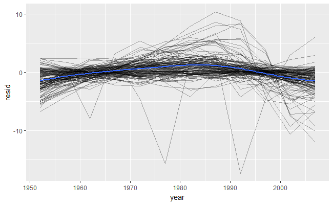

```r
resids %>%
  ggplot(aes(year, resid)) +
    geom_line(aes(group = country), alpha = 1 / 3) +
    geom_smooth(se = FALSE)
```

按大陆进行分组，分别绘制残差图：

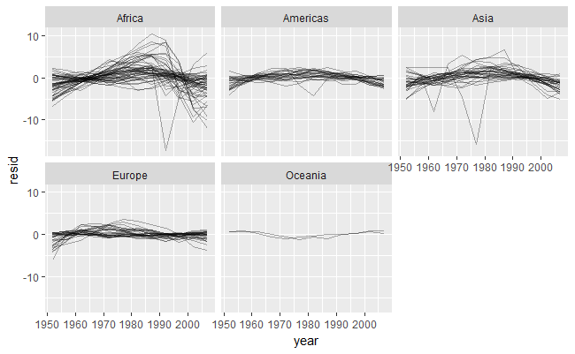

```r
resids %>%
  ggplot(aes(year, resid, group = country)) +
    geom_line(alpha = 1 / 3) +
    facet_wrap(~continent)
```

## 2.4 模型评价

`broom::glance()` 函数可以给出一些模型评价指标：

```r
broom::glance(nz_mod)
```

| r.squared | adj.r.squared | sigma | statistic | p.value | df | logLik | AIC | BIC | deviance | df.residual |
| --- | --- | --- | --- | --- | --- | --- | --- | --- | --- | --- |
| 0.9535846 | 0.9489431 | 0.8043472 | 205.4459 | 5.407324e-08 | 2 | -13.32064 | 32.64128 | 34.096 | 6.469743 | 10 |

使用 `mutate()` 和 `unnest()` 为每个模型添加评价指标：

```r
by_country %>%
  mutate(glance = map(model, broom::glance)) %>%
  unnest(glance)
```

| country | continent | data | model | resids | r.squared | adj.r.squared | sigma | statistic | p.value | df | logLik | AIC | BIC | deviance | df.residual |
| --- | --- | --- | --- | --- | --- | --- | --- | --- | --- | --- | --- | --- | --- | --- | --- |
| Afghanistan | Asia |  |  |  | 0.94771226 | 0.942483483 | 1.2227880 | 181.2494098 | 9.835213e-08 | 2 | -18.3469348 | 42.6938697 | 44.148590 | 14.9521045 | 10 |
| Albania | Europe |  |  |  | 0.91057777 | 0.901635545 | 1.9830615 | 101.8290138 | 1.462763e-06 | 2 | -24.1490356 | 54.2980711 | 55.752791 | 39.3253302 | 10 |
| Algeria | Africa |  |  |  | 0.98511721 | 0.983628932 | 1.3230064 | 661.9170864 | 1.808143e-10 | 2 | -19.2922136 | 44.5844272 | 46.039147 | 17.5034589 | 10 |
| Angola | Africa |  |  |  | 0.88781463 | 0.876596093 | 1.4070091 | 79.1381823 | 4.593498e-06 | 2 | -20.0309283 | 46.0618566 | 47.516577 | 19.7967471 | 10 |
| Argentina | Americas |  |  |  | 0.99556810 | 0.995124905 | 0.2923072 | 2246.3663487 | 4.215567e-13 | 2 | -1.1739328 | 8.3478656 | 9.802586 | 0.8544349 | 10 |
| Australia | Oceania |  |  |  | 0.97964774 | 0.977612511 | 0.6206086 | 481.3458627 | 8.667222e-10 | 2 | -10.2086767 | 26.4173534 | 27.872073 | 3.8515501 | 10 |
| Austria | Europe |  |  |  | 0.99213401 | 0.991347414 | 0.4074094 | 1261.2962902 | 7.435240e-12 | 2 | -5.1580921 | 16.3161841 | 17.770904 | 1.6598240 | 10 |
| Bahrain | Asia |  |  |  | 0.96673981 | 0.963413791 | 1.6395865 | 290.6597394 | 1.015855e-08 | 2 | -21.8666623 | 49.7333245 | 51.188044 | 26.8824402 | 10 |
| Bangladesh | Asia |  |  |  | 0.98936087 | 0.988296956 | 0.9766908 | 929.9263688 | 3.369501e-11 | 2 | -15.6503116 | 37.3006231 | 38.755343 | 9.5392498 | 10 |
| Belgium | Europe |  |  |  | 0.99454056 | 0.993994612 | 0.2929025 | 1821.6883955 | 1.196280e-12 | 2 | -1.1983465 | 8.3966931 | 9.851413 | 0.8579187 | 10 |

[output cut: 132 more lines]

```
#> # A tibble: 142 × 16
#>        country continent              data    model            resids r.squared
#>         <fctr>    <fctr>            <list>   <list>            <list>     <dbl>
#> 1  Afghanistan      Asia <tibble [12 × 4]> <S3: lm> <tibble [12 × 5]> 0.9477123
#> 2      Albania    Europe <tibble [12 × 4]> <S3: lm> <tibble [12 × 5]> 0.9105778
#> 3      Algeria    Africa <tibble [12 × 4]> <S3: lm> <tibble [12 × 5]> 0.9851172
#> 4       Angola    Africa <tibble [12 × 4]> <S3: lm> <tibble [12 × 5]> 0.8878146
#> 5    Argentina  Americas <tibble [12 × 4]> <S3: lm> <tibble [12 × 5]> 0.9955681
#> 6    Australia   Oceania <tibble [12 × 4]> <S3: lm> <tibble [12 × 5]> 0.9796477
#> 7      Austria    Europe <tibble [12 × 4]> <S3: lm> <tibble [12 × 5]> 0.9921340
#> 8      Bahrain      Asia <tibble [12 × 4]> <S3: lm> <tibble [12 × 5]> 0.9667398
#> 9   Bangladesh      Asia <tibble [12 × 4]> <S3: lm> <tibble [12 × 5]> 0.9893609
#> 10     Belgium    Europe <tibble [12 × 4]> <S3: lm> <tibble [12 × 5]> 0.9945406
#> # ... with 132 more rows, and 10 more variables: adj.r.squared <dbl>,
#> #   sigma <dbl>, statistic <dbl>, p.value <dbl>, df <int>, logLik <dbl>,
#> #   AIC <dbl>, BIC <dbl>, deviance <dbl>, df.residual <int>
```

使用 `.drop = TRUE` 参数，丢弃所有的列表-列：

```r
glance <- by_country %>%
  mutate(glance = map(model, broom::glance)) %>%
  unnest(glance, .drop = TRUE)
glance
```

| country | continent | r.squared | adj.r.squared | sigma | statistic | p.value | df | logLik | AIC | BIC | deviance | df.residual |
| --- | --- | --- | --- | --- | --- | --- | --- | --- | --- | --- | --- | --- |
| Afghanistan | Asia | 0.94771226 | 0.942483483 | 1.2227880 | 181.2494098 | 9.835213e-08 | 2 | -18.3469348 | 42.6938697 | 44.148590 | 14.9521045 | 10 |
| Albania | Europe | 0.91057777 | 0.901635545 | 1.9830615 | 101.8290138 | 1.462763e-06 | 2 | -24.1490356 | 54.2980711 | 55.752791 | 39.3253302 | 10 |
| Algeria | Africa | 0.98511721 | 0.983628932 | 1.3230064 | 661.9170864 | 1.808143e-10 | 2 | -19.2922136 | 44.5844272 | 46.039147 | 17.5034589 | 10 |
| Angola | Africa | 0.88781463 | 0.876596093 | 1.4070091 | 79.1381823 | 4.593498e-06 | 2 | -20.0309283 | 46.0618566 | 47.516577 | 19.7967471 | 10 |
| Argentina | Americas | 0.99556810 | 0.995124905 | 0.2923072 | 2246.3663487 | 4.215567e-13 | 2 | -1.1739328 | 8.3478656 | 9.802586 | 0.8544349 | 10 |
| Australia | Oceania | 0.97964774 | 0.977612511 | 0.6206086 | 481.3458627 | 8.667222e-10 | 2 | -10.2086767 | 26.4173534 | 27.872073 | 3.8515501 | 10 |
| Austria | Europe | 0.99213401 | 0.991347414 | 0.4074094 | 1261.2962902 | 7.435240e-12 | 2 | -5.1580921 | 16.3161841 | 17.770904 | 1.6598240 | 10 |
| Bahrain | Asia | 0.96673981 | 0.963413791 | 1.6395865 | 290.6597394 | 1.015855e-08 | 2 | -21.8666623 | 49.7333245 | 51.188044 | 26.8824402 | 10 |
| Bangladesh | Asia | 0.98936087 | 0.988296956 | 0.9766908 | 929.9263688 | 3.369501e-11 | 2 | -15.6503116 | 37.3006231 | 38.755343 | 9.5392498 | 10 |
| Belgium | Europe | 0.99454056 | 0.993994612 | 0.2929025 | 1821.6883955 | 1.196280e-12 | 2 | -1.1983465 | 8.3966931 | 9.851413 | 0.8579187 | 10 |

[output cut: 132 more lines]

```
#> # A tibble: 142 × 13
#>       country continent r.squared adj.r.squared sigma statistic  p.value
#>        <fctr>    <fctr>     <dbl>         <dbl> <dbl>     <dbl>    <dbl>
#> 1 Afghanistan      Asia     0.948         0.942 1.223     181.2 9.84e-08
#> 2     Albania    Europe     0.911         0.902 1.983     101.8 1.46e-06
#> 3     Algeria    Africa     0.985         0.984 1.323     661.9 1.81e-10
#> 4      Angola    Africa     0.888         0.877 1.407      79.1 4.59e-06
#> 5   Argentina  Americas     0.996         0.995 0.292    2246.4 4.22e-13
#> 6   Australia   Oceania     0.980         0.978 0.621     481.3 8.67e-10
#> # ... with 136 more rows, and 6 more variables: df <int>, logLik <dbl>,
#> #   AIC <dbl>, BIC <dbl>, deviance <dbl>, df.residual <int>
```

找出拟合效果较差的模型，可以发现 $R^2$ 较低的模型都集中在非洲：

```r
glance %>%
  arrange(r.squared)
```

| country | continent | r.squared | adj.r.squared | sigma | statistic | p.value | df | logLik | AIC | BIC | deviance | df.residual |
| --- | --- | --- | --- | --- | --- | --- | --- | --- | --- | --- | --- | --- |
| Rwanda | Africa | 0.01715964 | -0.081124401 | 6.5582695 | 0.1745923 | 6.848927e-01 | 2 | -38.5020543 | 83.0041086 | 84.458829 | 430.1089854 | 10 |
| Botswana | Africa | 0.03402340 | -0.062574259 | 6.1121773 | 0.3522177 | 5.660414e-01 | 2 | -37.6567298 | 81.3134597 | 82.768180 | 373.5871172 | 10 |
| Zimbabwe | Africa | 0.05623196 | -0.038144842 | 7.2054307 | 0.5958240 | 4.580290e-01 | 2 | -39.6313531 | 85.2627062 | 86.717426 | 519.1823151 | 10 |
| Zambia | Africa | 0.05983644 | -0.034179918 | 4.5287128 | 0.6364471 | 4.435318e-01 | 2 | -34.0585860 | 74.1171720 | 75.571892 | 205.0923944 | 10 |
| Swaziland | Africa | 0.06821087 | -0.024968046 | 6.6440913 | 0.7320419 | 4.122530e-01 | 2 | -38.6580683 | 83.3161365 | 84.770856 | 441.4394929 | 10 |
| Lesotho | Africa | 0.08485635 | -0.006658011 | 5.9339335 | 0.9272463 | 3.582864e-01 | 2 | -37.3015809 | 80.6031617 | 82.057882 | 352.1156687 | 10 |
| Cote d'Ivoire | Africa | 0.28337240 | 0.211709644 | 3.9255904 | 3.9542491 | 7.480350e-02 | 2 | -32.3435343 | 70.6870685 | 72.141788 | 154.1026019 | 10 |
| South Africa | Africa | 0.31246865 | 0.243715518 | 4.7443562 | 4.5447914 | 5.883744e-02 | 2 | -34.6168020 | 75.2336040 | 76.688324 | 225.0891578 | 10 |
| Uganda | Africa | 0.34215382 | 0.276369202 | 3.1876683 | 5.2011219 | 4.573928e-02 | 2 | -29.8448096 | 65.6896193 | 67.144339 | 101.6122930 | 10 |
| Congo, Dem. Rep. | Africa | 0.34820278 | 0.283023054 | 2.4294888 | 5.3421948 | 4.340981e-02 | 2 | -26.5855035 | 59.1710069 | 60.625727 | 59.0241587 | 10 |

[output cut: 132 more lines]

```
#> # A tibble: 142 × 13
#>     country continent r.squared adj.r.squared sigma statistic p.value
#>      <fctr>    <fctr>     <dbl>         <dbl> <dbl>     <dbl>   <dbl>
#> 1    Rwanda    Africa    0.0172      -0.08112  6.56     0.175   0.685
#> 2  Botswana    Africa    0.0340      -0.06257  6.11     0.352   0.566
#> 3  Zimbabwe    Africa    0.0562      -0.03814  7.21     0.596   0.458
#> 4    Zambia    Africa    0.0598      -0.03418  4.53     0.636   0.444
#> 5 Swaziland    Africa    0.0682      -0.02497  6.64     0.732   0.412
#> 6   Lesotho    Africa    0.0849      -0.00666  5.93     0.927   0.358
#> # ... with 136 more rows, and 6 more variables: df <int>, logLik <dbl>,
#> #   AIC <dbl>, BIC <dbl>, deviance <dbl>, df.residual <int>
```

由于 `continent` 为离散变量，可以使用 `geom_jitter()` 来绘制 $R^2$ 的扰动点图：

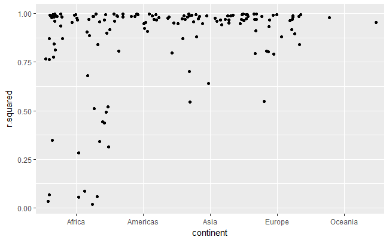

```r
glance %>%
  ggplot(aes(continent, r.squared)) +
    geom_jitter(width = 0.5)
```

绘制 $R^2$ 较差的国家的期望寿命折线图：

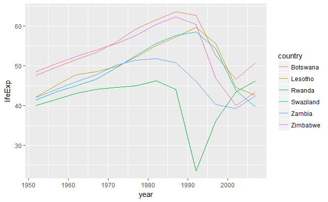

```r
bad_fit <- filter(glance, r.squared < 0.25)
gapminder %>%
  semi_join(bad_fit, by = "country") %>%
  ggplot(aes(year, lifeExp, colour = country)) +
    geom_line()
```

可以发现两个主要的影响因素：HIV/AIDS 传染病和卢旺达大屠杀。

# 3 列表-列

列表-列隐含在数据框的定义中：数据框本质上是一个包含了一系列有命名的等长向量的列表。列表同时也是向量，所以将列表当做数据框的一列也是合理的。然而，原生 R 处理列表-列并不方便， `data.frame()` 会将列表转换为列的列表，即数据框：

```r
data.frame(x = list(1:3, 3:5))
```

| x.1.3 | x.3.5 |
| --- | --- |
| 1 | 3 |
| 2 | 4 |
| 3 | 5 |

```
#>   x.1.3 x.3.5
#> 1     1     3
#> 2     2     4
#> 3     3     5
```

使用 `I()` 可以防止 `data.frame()` 进行这样的转换，但是显示的效果很不直观：

```r
data.frame(
  x = I(list(1:3, 3:5)),
  y = c("1, 2", "3, 4, 5")
)
```

| x | y |
| --- | --- |
|  | 1, 2 |
|  | 3, 4, 5 |

```
#>         x       y
#> 1 1, 2, 3    1, 2
#> 2 3, 4, 5 3, 4, 5
```

`tibble()` 不会改变输入的格式，所以保留了列表-列的数据格式，并且会加以显示 `<list>` ：

```r
tibble(
  x = list(1:3, 3:5),
  y = c("1, 2", "3, 4, 5")
)
```

| x | y |
| --- | --- |
|  | 1, 2 |
|  | 3, 4, 5 |

```
#> # A tibble: 2 × 2
#>           x       y
#>      <list>   <chr>
#> 1 <int [3]>    1, 2
#> 2 <int [3]> 3, 4, 5
```

`tribble()` 还会自动识别并将输入转换为列表-列：

```r
tribble(
   ~x, ~y,
  1:3, "1, 2",
  3:5, "3, 4, 5"
)
```

| x | y |
| --- | --- |
|  | 1, 2 |
|  | 3, 4, 5 |

```
#> # A tibble: 2 × 2
#>           x       y
#>      <list>   <chr>
#> 1 <int [3]>    1, 2
#> 2 <int [3]> 3, 4, 5
```

列表-列作为过渡用的数据结构非常有用。通常来说，列表-列的工作流程中有三个重要部分：

- 使用 `nest()` 、 `summarise()` + `list()` 、 `mutate()` + `map` 函数族的方式创建列表-列。
- 对已有的列表-列使用 `map()` 、 `map2()` 、 `pmap()` 函数，生成新的列表-列。
- 将列表-列转换为常规列

# 4 创建列表-列

通常不会使用 `tibble()` 创建列表-列，而是使用以下四种方式从常规列中创建列表-列：

- 1 使用 `tidyr::nest()` 将分组数据框转换为嵌套数据框
- 2 使用 `mutate()` 和返回列表的向量化函数
- 3 使用 `summarise()` 和返回多结果的汇总函数
- 4 使用 `tibble::enframe()` 从有命名的列表中创建列表-列。

## 4.1 `nest()` 函数

`nest()` 可以创建嵌套数据框，即包含列表-列的数据框。在嵌套数据框中，每一行都是一个元观测（meta-observation）：其他常规列定义观测，例如上文中的 `country` 和 `continent` ，列表-列包含该元观测的信息。

有两种使用 `nest()` 的方法：

- 对分组数据框使用 `nest()` ，分组列不变，将其他列组合成列表-列：

```r
gapminder %>%
  group_by(country, continent) %>%
  nest()
```

| country | continent | data |
| --- | --- | --- |
| Afghanistan | Asia |  |
| Albania | Europe |  |
| Algeria | Africa |  |
| Angola | Africa |  |
| Argentina | Americas |  |
| Australia | Oceania |  |
| Austria | Europe |  |
| Bahrain | Asia |  |
| Bangladesh | Asia |  |
| Belgium | Europe |  |

[output cut: 132 more lines]

```
#> # A tibble: 142 × 3
#>       country continent              data
#>        <fctr>    <fctr>            <list>
#> 1 Afghanistan      Asia <tibble [12 × 4]>
#> 2     Albania    Europe <tibble [12 × 4]>
#> 3     Algeria    Africa <tibble [12 × 4]>
#> 4      Angola    Africa <tibble [12 × 4]>
#> 5   Argentina  Americas <tibble [12 × 4]>
#> 6   Australia   Oceania <tibble [12 × 4]>
#> # ... with 136 more rows
```

- 对未分组数据框使用 `nest()` ，选择需要嵌套进列表-列的列：

```r
gapminder %>%
  nest(year:gdpPercap)
```

| country | continent | data |
| --- | --- | --- |
| Afghanistan | Asia |  |
| Albania | Europe |  |
| Algeria | Africa |  |
| Angola | Africa |  |
| Argentina | Americas |  |
| Australia | Oceania |  |
| Austria | Europe |  |
| Bahrain | Asia |  |
| Bangladesh | Asia |  |
| Belgium | Europe |  |

[output cut: 132 more lines]

```
#> # A tibble: 142 × 3
#>       country continent              data
#>        <fctr>    <fctr>            <list>
#> 1 Afghanistan      Asia <tibble [12 × 4]>
#> 2     Albania    Europe <tibble [12 × 4]>
#> 3     Algeria    Africa <tibble [12 × 4]>
#> 4      Angola    Africa <tibble [12 × 4]>
#> 5   Argentina  Americas <tibble [12 × 4]>
#> 6   Australia   Oceania <tibble [12 × 4]>
#> # ... with 136 more rows
```

## 4.2 返回列表的向量化函数

一些函数接收原子向量，返回列表。例如 `stringr` 模块中的 `stringr::str_split()` ，接收字符向量，返回字符向量的列表：

```r
df <- tribble(
  ~x1,
  "a,b,c",
  "d,e,f,g"
)
df %>%
  mutate(x2 = stringr::str_split(x1, ","))
```

| x1 | x2 |
| --- | --- |
| a,b,c |  |
| d,e,f,g |  |

```
#> # A tibble: 2 × 2
#>        x1        x2
#>     <chr>    <list>
#> 1   a,b,c <chr [3]>
#> 2 d,e,f,g <chr [4]>
```

使用 `unnest()` 可以解嵌套：

```r
df %>%
  mutate(x2 = stringr::str_split(x1, ",")) %>%
  unnest()
```

| x1 | x2 |
| --- | --- |
| a,b,c | a |
| a,b,c | b |
| a,b,c | c |
| d,e,f,g | d |
| d,e,f,g | e |
| d,e,f,g | f |
| d,e,f,g | g |

```
#> # A tibble: 7 × 2
#>        x1    x2
#>     <chr> <chr>
#> 1   a,b,c     a
#> 2   a,b,c     b
#> 3   a,b,c     c
#> 4 d,e,f,g     d
#> 5 d,e,f,g     e
#> 6 d,e,f,g     f
#> # ... with 1 more rows
```

```r
df %>%
  mutate(x2 = stringr::str_split(x1, ",")) %>%
  tidyr::separate_rows(x2)
```

| x1 | x2 |
| --- | --- |
| a,b,c | c |
| a,b,c | a |
| a,b,c | b |
| a,b,c | c |
| a,b,c |  |
| d,e,f,g | c |
| d,e,f,g | d |
| d,e,f,g | e |
| d,e,f,g | f |
| d,e,f,g | g |

[output cut: 1 more lines]

另一个例子是使用 `map()` 、 `map2()` 、 `pmap()` 类函数：

```r
sim <- tribble(
  ~f,      ~params,
  "runif", list(min = -1, max = -1),
  "rnorm", list(sd = 5),
  "rpois", list(lambda = 10)
)
sim %>%
  mutate(sims = invoke_map(f, params, n = 10))
```

| f | params | sims |
| --- | --- | --- |
| runif |  |  |
| rnorm |  |  |
| rpois |  |  |

```
#> # A tibble: 3 × 3
#>       f     params       sims
#>   <chr>     <list>     <list>
#> 1 runif <list [2]> <dbl [10]>
#> 2 rnorm <list [1]> <dbl [10]>
#> 3 rpois <list [1]> <int [10]>
```

## 4.3 返回多结果的汇总函数

`summarise()` 的缺陷在于只能与返回一个结果的汇总函数合用，如果和 `quantile()` 这种返回任意长度向量的函数合用会报错：

```r
mtcars %>%
  group_by(cyl) %>%
  summarise(q = quantile(mpg))
```

```
Error in summarise_impl(.data, dots) : expecting a single value
```

为应对这种情况，可以将结果封装在列表中：

```r
mtcars %>%
  group_by(cyl) %>%
  summarise(q = list(quantile(mpg)))
```

| cyl | q |
| --- | --- |
| 4 |  |
| 6 |  |
| 8 |  |

```
#> # A tibble: 3 × 2
#>     cyl         q
#>   <dbl>    <list>
#> 1     4 <dbl [5]>
#> 2     6 <dbl [5]>
#> 3     8 <dbl [5]>
```

使用 `unnest()` 可以解嵌套：

```r
probs <- c(0.01, 0.25, 0.5, 0.75, 0.99)
mtcars %>%
  group_by(cyl) %>%
  summarise(p = list(probs), q = list(quantile(mpg, probs))) %>%
  unnest()
```

| cyl | p | q |
| --- | --- | --- |
| 4 | 0.01 | 21.410 |
| 4 | 0.25 | 22.800 |
| 4 | 0.50 | 26.000 |
| 4 | 0.75 | 30.400 |
| 4 | 0.99 | 33.750 |
| 6 | 0.01 | 17.818 |
| 6 | 0.25 | 18.650 |
| 6 | 0.50 | 19.700 |
| 6 | 0.75 | 21.000 |
| 6 | 0.99 | 21.376 |

[output cut: 5 more lines]

```
#> # A tibble: 15 × 3
#>     cyl     p     q
#>   <dbl> <dbl> <dbl>
#> 1     4  0.01  21.4
#> 2     4  0.25  22.8
#> 3     4  0.50  26.0
#> 4     4  0.75  30.4
#> 5     4  0.99  33.8
#> 6     6  0.01  17.8
#> # ... with 9 more rows
```

## 4.4 有命名的列表

如果想要同时对列表元素的名字和内容进行循环，可以用 `tibble::enframe()` 创建数据框：

```r
x <- list(
  a = 1:5,
  b = 3:4,
  c = 5:6
)
df <- enframe(x)
df
```

| name | value |
| --- | --- |
| a |  |
| b |  |
| c |  |

```
#> # A tibble: 3 × 2
#>    name     value
#>   <chr>    <list>
#> 1     a <int [5]>
#> 2     b <int [2]>
#> 3     c <int [2]>
```

使用 `map2()` 同时对元素名 `name` 和内容 `value` 进行循环：

```r
df %>%
  mutate(
    smry = map2_chr(name, value, ~ stringr::str_c(.x, ": ", .y[1]))
  )
```

| name | value | smry |
| --- | --- | --- |
| a |  | a: 1 |
| b |  | b: 3 |
| c |  | c: 5 |

```
#> # A tibble: 3 × 3
#>    name     value  smry
#>   <chr>    <list> <chr>
#> 1     a <int [5]>  a: 1
#> 2     b <int [2]>  b: 3
#> 3     c <int [2]>  c: 5
```

# 5 列表-列转换为常规列

为了应用数据转换、数据可视化的技术，需要将列表-列转换为常规列。转换的方法取决于每个元观测会产出一个值还是多个值：

- 1 如果产出一个值，使用 `mutate()` 和 `map_lgl()` 、 `map_int()` 、 `map_dbl()` 、 `map_chr()` 生成一个原子向量
- 2 如果产出多个值，使用 `unnest()` ，每个元观测都会重复必要的次数

## 5.1 列表-列转换为向量

如果可以将列表-列转换为原子向量，就可以将其作为一个常规列。例如，返回一个对象的数据类型和长度：

```r
df <- tribble(
  ~x,
  letters[1:5],
  1:3,
  runif(5)
)

df %>% mutate(
  type = map_chr(x, typeof),
  length = map_int(x, length)
)
```

| x | type | length |
| --- | --- | --- |
|  | character | 5 |
|  | integer | 3 |
|  | double | 5 |

```
#> # A tibble: 3 × 3
#>           x      type length
#>      <list>     <chr>  <int>
#> 1 <chr [5]> character      5
#> 2 <int [3]>   integer      3
#> 3 <dbl [5]>    double      5
```

也可以利用 `map_*()` 函数族的快捷操作，将嵌套的列表-列转换为常规列，同时用 `.null` 参数填充缺失值：

```r
df <- tribble(
  ~x,
  list(a = 1, b = 2),
  list(a = 2, c = 4)
)
df %>% mutate(
  a = map_dbl(x, "a"),
  b = map_dbl(x, "b", .null = NA_real_)
)
```

| x | a | b |
| --- | --- | --- |
|  | 1 | 2 |
|  | 2 | NA |

```
#> # A tibble: 2 × 3
#>            x     a     b
#>       <list> <dbl> <dbl>
#> 1 <list [2]>     1     2
#> 2 <list [2]>     2    NA
```

## 5.2 解嵌套

`unnest()` 的工作原理是列表-列中有多少个元素，就对常规列重复多少次：

```r
tibble(x = 1:2, y = list(1:4, 1)) %>% unnest(y)
```

| x | y |
| --- | --- |
| 1 | 1 |
| 1 | 2 |
| 1 | 3 |
| 1 | 4 |
| 2 | 1 |

```
#> # A tibble: 5 × 2
#>       x     y
#>   <int> <dbl>
#> 1     1     1
#> 2     1     2
#> 3     1     3
#> 4     1     4
#> 5     2     1
```

因此，不能同时解嵌套两个元素个数不同的列表-列：

```r
# Ok, because y and z have the same number of elements in
# every row
df1 <- tribble(
  ~x, ~y,           ~z,
   1, c("a", "b"), 1:2,
   2, "c",           3
)
df1
```

| x | y | z |
| --- | --- | --- |
| 1 |  |  |
| 2 |  |  |

```
#> # A tibble: 2 × 3
#>       x         y         z
#>   <dbl>    <list>    <list>
#> 1     1 <chr [2]> <int [2]>
#> 2     2 <chr [1]> <dbl [1]>
```

```r
df1 %>% unnest(y, z)
```

| x | y | z |
| --- | --- | --- |
| 1 | a | 1 |
| 1 | b | 2 |
| 2 | c | 3 |

```
#> # A tibble: 3 × 3
#>       x     y     z
#>   <dbl> <chr> <dbl>
#> 1     1     a     1
#> 2     1     b     2
#> 3     2     c     3
```

```r
# Doesn't work because y and z have different number of elements
df2 <- tribble(
  ~x, ~y,           ~z,
   1, "a",         1:2,
   2, c("b", "c"),   3
)
df2
```

| x | y | z |
| --- | --- | --- |
| 1 |  |  |
| 2 |  |  |

```
#> # A tibble: 2 × 3
#>       x         y         z
#>   <dbl>    <list>    <list>
#> 1     1 <chr [1]> <int [2]>
#> 2     2 <chr [2]> <dbl [1]>
```

```r
df2 %>% unnest(y, z)
```

```
Error: All nested columns must have the same number of elements.
```

# 6 用 `broom` 包创建规整数据